# Sacred Values Signal Trustworthiness — Reproducibility Pipeline (Studies 4 & 5)

Push-button reproduction of the parallel-mediation tests for the two-stage mechanism

Sacred Values project

Knitted 09 August 2026

# 1 What this document is

This is the companion to the Studies 1 & 2 pipeline, covering **Studies 4 and 5 — the two-stage mechanism**. Knitting it from a clean R session reproduces, from the raw OSF data, every test the manuscript reports for these studies. For each study it works in three steps: first the **basic between-condition effect** (does the sacred commitment raise trust and social acceptance at all?), reported with both the effect size *r* (= Z/sqrt(N)) and the common-language effect size (CLES); then the **moral-foundation “halo”** (does the sacred display raise perceived sacralization on each of the five foundations?); and finally the **competing-mediator paths to trust** (which foundations actually carry trust?). Each computed value is audited in-document against the number printed in the manuscript.

It follows the same **push-button replication** standard (Wood, Müller & Brown, *PLOS ONE* 2018): one self-contained `.Rmd`, raw data read directly, no machine-specific paths, sample sizes asserted, manuscript values declared as advance targets, fixed seeds, full `sessionInfo()` footer.

**Method (per manuscript *Statistical analysis*).** Studies 4–5 enter all five perceived foundations as **parallel competing mediators** in a single structural model, with **5,000 bootstrap resamples** and **percentile** 95% confidence intervals. We fit this with `lavaan`, mirroring the original analysis.

> **A note on the `lavaan` variance warning.** The mediators (perceived sacralization, ~0–1) and the outcomes (0–100 ratings) live on very different scales, so `lavaan` prints a “variances … a factor 1000 times larger” note. This is cosmetic — it reflects the original measurement scales and does not affect the estimates — so we suppress it inside the fitting function.

# 2 Setup

## 2.1 Packages, seed, parameters, and data location

```r
suppressPackageStartupMessages({
  library(haven)    # read SPSS .sav
  library(dplyr)    # data manipulation
  library(lavaan)   # parallel mediation (SEM) with bootstrap CIs
  library(coin)     # exact-distribution Mann-Whitney (standardized Z)
  library(ggplot2)  # forest plots
  library(tibble)   # tidy result tables
  library(knitr)    # kable tables
})

set.seed(20260619)        # global document seed
N_BOOT  <- 5000L          # bootstrap resamples (manuscript: 5,000)
BOOT_SEED <- 2024L        # seed fixed inside each model for reproducible CIs
```

```r
find_data_root <- function(start = getwd(), marker = "data") {
  d <- normalizePath(start, winslash = "/", mustWork = FALSE)
  repeat {
    if (dir.exists(file.path(d, marker))) return(d)
    parent <- dirname(d)
    if (identical(parent, d)) {
      stop("Could not locate the '", marker, "' directory by walking up from ",
           start, ".\n  Set DATA_DIR manually in this chunk.", call. = FALSE)
    }
    d <- parent
  }
}

DATA_DIR <- file.path(find_data_root(), "data")   # <- override here if needed

s4_file <- file.path(DATA_DIR,
  "Study 4 - Pork Investment - Moral Character Mediation", "OSF SV Trust - Study 4.sav")
s5_file <- file.path(DATA_DIR,
  "Study 5 - Environmental Sacred Values", "OSF Study 5.sav")

stopifnot(
  "Study 4 .sav not found" = file.exists(s4_file),
  "Study 5 .sav not found" = file.exists(s5_file)
)
cat("Data directory:\n  ", DATA_DIR, "\n")
```

```
## Data directory:
##    /Users/thandfie/Library/CloudStorage/Dropbox/Toby-Ji-shared-folder/Sacred Values Experiment/paper/PNAS version/sacred-values-reproducibility/data
```

## 2.2 Parallel-mediation engine

A single function builds and fits the competing-mediator model for any outcome, IV, and set of five mediators, returning tidy tables for the **indirect effects** and the **halo (a-paths)**. Defined in the open so every step is auditable.

```r
# Basic between-condition effect (before any mediation) ------------------------
# Probability of superiority / common-language effect size (CLES):
# P(a random draw from the sacred condition exceeds one from non-sacred);
# ties contribute 1/2. Same definition as the Studies 1 & 2 pipeline.
prob_superiority <- function(high, low) {
  high <- high[!is.na(high)]; low <- low[!is.na(low)]
  mean(outer(high, low, function(a, b) (a > b) + 0.5 * (a == b)))
}

# One outcome's between-condition contrast: descriptives, rank-based Mann-Whitney
# U (with standardized Z and effect size r = Z / sqrt(N)), and CLES. `iv` is a
# 0/1 condition code with 1 = sacred. Returns a tidy one-row tibble.
basic_contrast <- function(data, iv, dv, label) {
  x  <- as.numeric(data[[iv]]); y <- as.numeric(data[[dv]])
  ok <- !is.na(x) & !is.na(y); x <- x[ok]; y <- y[ok]
  g  <- factor(x, levels = c(0, 1), labels = c("Non-sacred", "Sacred"))
  N  <- length(y); n1 <- sum(x == 0); n2 <- sum(x == 1)

  wt <- coin::wilcox_test(y ~ g, distribution = "asymptotic")
  Z  <- abs(as.numeric(coin::statistic(wt, type = "standardized")))
  p  <- coin::pvalue(wt)
  w  <- stats::wilcox.test(y ~ g, exact = FALSE, correct = FALSE)
  U1 <- as.numeric(w$statistic); U2 <- n1 * n2 - U1

  r_full <- Z / sqrt(N)   # from the UNROUNDED Z: inside tibble() the rounded Z column
                          # would mask the outer Z and bias r at rounding boundaries
  tibble(Outcome   = label,
         M_sacred  = round(mean(y[x == 1]), 1), SD_sacred = round(sd(y[x == 1]), 1),
         M_nonsac  = round(mean(y[x == 0]), 1), SD_nonsac = round(sd(y[x == 0]), 1),
         U         = max(U1, U2),
         Z         = round(Z, 2),
         p         = signif(p, 2),
         r         = round(r_full, 2),
         CLES      = round(prob_superiority(y[x == 1], y[x == 0]), 3))
}

# Build lavaan syntax for a parallel mediation with k mediators -----------------
# Beyond the five indirect effects we also declare the TOTAL effect
# (c' + sum a*b) and each foundation's indirect effect as a *share of the total
# effect* (prop%d) plus the overall proportion mediated. lavaan bootstraps these
# defined parameters automatically, so their percentile CIs come for free and
# the anchoring numbers the manuscript reports are themselves reproduced here.
parallel_med_syntax <- function(dv, iv, mediators) {
  k         <- seq_along(mediators)
  b_terms   <- paste(sprintf("b%d*%s", k, mediators), collapse = " + ")
  a_lines   <- paste(sprintf("%s ~ a%d*%s", mediators, k, iv), collapse = "\n")
  ind_def   <- paste(sprintf("ind%d := a%d*b%d", k, k, k), collapse = "\n")
  tot_def   <- sprintf("total_indirect := %s",
                       paste(sprintf("a%d*b%d", k, k), collapse = " + "))
  teff_def  <- "total_effect := c + total_indirect"
  prop_def  <- paste(sprintf("prop%d := ind%d/total_effect", k, k), collapse = "\n")
  pmed_def  <- "prop_mediated := total_indirect/total_effect"
  paste(sprintf("%s ~ %s + c*%s", dv, b_terms, iv), a_lines, ind_def, tot_def,
        teff_def, prop_def, pmed_def, sep = "\n")
}

# Fit the model with bootstrap, percentile CIs ---------------------------------
fit_parallel_med <- function(data, dv, iv, mediators,
                             n_boot = N_BOOT, seed = BOOT_SEED) {
  set.seed(seed)
  fit <- suppressWarnings(lavaan::sem(
    parallel_med_syntax(dv, iv, mediators),
    data = data, se = "bootstrap", bootstrap = n_boot))
  pe <- lavaan::parameterEstimates(fit, ci = TRUE, boot.ci.type = "perc",
                                   standardized = TRUE)
  list(fit = fit, pe = pe, n = lavaan::lavInspect(fit, "ntotal"),
       mediators = mediators, labels = names(mediators))
}

# Tidy the five indirect effects (route to the outcome) ------------------------
# `Pct_total` anchors each raw indirect effect to the total effect, giving
# "Harm ~X% of the trust effect" rather than an uninterpretable raw B.
tidy_indirect <- function(res) {
  k   <- seq_along(res$mediators)
  pe  <- res$pe[match(sprintf("ind%d", k), res$pe$label), ]
  pr  <- res$pe[match(sprintf("prop%d", k), res$pe$label), ]
  tibble(Foundation = res$labels,
         B        = round(pe$est, 2),
         CI_low   = round(pe$ci.lower, 2),
         CI_high  = round(pe$ci.upper, 2),
         Pct_total = round(100 * pr$est, 1),
         beta_std = round(pe$std.all, 3),
         Mediates = ifelse(pe$ci.lower > 0 | pe$ci.upper < 0, "yes", "no"))
}

# Total effect of the IV on the outcome, in outcome-scale points, with its CI.
get_total_effect <- function(res) {
  te <- res$pe[res$pe$label == "total_effect", ]
  ti <- res$pe[res$pe$label == "total_indirect", ]
  pm <- res$pe[res$pe$label == "prop_mediated", ]
  list(total = te$est, total_lo = te$ci.lower, total_hi = te$ci.upper,
       indirect = ti$est, prop_mediated = pm$est)
}

# Full decomposition table for the SI: mediator M/SD, a-path (IV -> mediator),
# b-path (mediator -> outcome), indirect effect, its % of the total effect, and
# the standardized indirect effect. This is the table that makes B interpretable.
tidy_decomp <- function(res, data) {
  k   <- seq_along(res$mediators)
  ci  <- function(row) sprintf("[%.2f, %.2f]", row$ci.lower, row$ci.upper)
  a   <- res$pe[match(sprintf("a%d", k), res$pe$label), ]
  b   <- res$pe[match(sprintf("b%d", k), res$pe$label), ]
  ind <- res$pe[match(sprintf("ind%d", k), res$pe$label), ]
  pr  <- res$pe[match(sprintf("prop%d", k), res$pe$label), ]
  med_M  <- vapply(res$mediators, function(v) mean(data[[v]], na.rm = TRUE), numeric(1))
  med_SD <- vapply(res$mediators, function(v) sd(data[[v]],   na.rm = TRUE), numeric(1))
  tibble(Foundation = res$labels,
         M_SD      = sprintf("%.2f (%.2f)", med_M, med_SD),
         a_path    = sprintf("%.3f %s", a$est,  vapply(seq_len(nrow(a)), function(i) ci(a[i, ]), "")),
         b_path    = sprintf("%.2f %s",  b$est,  vapply(seq_len(nrow(b)), function(i) ci(b[i, ]), "")),
         Indirect  = sprintf("%.2f %s",  ind$est, vapply(seq_len(nrow(ind)), function(i) ci(ind[i, ]), "")),
         Pct_total = sprintf("%.1f%%",   100 * pr$est),
         beta_std  = round(ind$std.all, 3))
}

# Tidy the five a-paths (the moral halo: did the display raise each foundation?)-
tidy_halo <- function(res) {
  k  <- seq_along(res$mediators)
  pe <- res$pe[match(sprintf("a%d", k), res$pe$label), ]
  tibble(Foundation = res$labels,
         a        = round(pe$est, 3),
         CI_low   = round(pe$ci.lower, 3),
         CI_high  = round(pe$ci.upper, 3),
         p        = signif(pe$pvalue, 2),
         Raised   = ifelse(pe$pvalue < 0.05, "yes", "no"))
}

# Pull one indirect effect's point + CI for the audit table --------------------
get_indirect <- function(res, foundation) {
  i  <- match(foundation, res$labels)
  pe <- res$pe[res$pe$label == sprintf("ind%d", i), ]
  c(B = pe$est, lo = pe$ci.lower, hi = pe$ci.upper)
}

# Forest plot of the five indirect effects -------------------------------------
forest_indirect <- function(res, title) {
  df <- tidy_indirect(res)
  df$Foundation <- factor(df$Foundation, levels = rev(res$labels))
  ggplot(df, aes(B, Foundation, colour = Mediates)) +
    geom_vline(xintercept = 0, linetype = 2, colour = "grey50") +
    geom_pointrange(aes(xmin = CI_low, xmax = CI_high), linewidth = 0.7, size = 0.6) +
    scale_colour_manual(values = c(no = "#9aa0a6", yes = "#1a73e8"),
                        name = "Mediates trust\n(95% CI excl. 0)") +
    labs(title = title, x = "Indirect effect on trustworthiness (B)", y = NULL) +
    theme_minimal(base_size = 12)
}
```

```r
# One audit row: computed value vs the manuscript's reported value.
audit_row <- function(quantity, computed, claimed, tol, digits = 2) {
  fmt <- function(v) if (is.na(v)) "--" else formatC(v, format = "f", digits = digits)
  check <- if (is.na(claimed)) "not stated in text"
           else {
             d <- abs(computed - claimed)
             if (d <= tol) "match" else if (d <= 3 * tol) "close" else "DIFFERS"
           }
  tibble(Quantity = quantity, Manuscript = fmt(claimed),
         Computed = fmt(computed), Check = check)
}
```

```r
# --- SI reproduction helpers ---------------------------------------------------

# Shapiro-Wilk W (+ p, N) for a set of variables (SI normality tables).
shapiro_table <- function(data, vars) {
  do.call(rbind, lapply(seq_along(vars), function(i) {
    x  <- as.numeric(data[[vars[i]]]); x <- x[!is.na(x)]
    sw <- shapiro.test(x)
    tibble(Variable = names(vars)[i], W = round(unname(sw$statistic), 2),
           p = signif(sw$p.value, 2), N = length(x))
  }))
}

# Significance stars for a p-value.
star <- function(p) ifelse(p < .001, "***", ifelse(p < .01, "**", ifelse(p < .05, "*", "")))

# Lower-triangle Pearson correlation matrix (with stars) + trailing Mean / SD rows,
# reproducing the SI intercorrelation tables. `vars` is a named character vector.
intercorr_table <- function(data, vars) {
  lab <- names(vars); k <- length(vars)
  X <- sapply(vars, function(v) as.numeric(data[[v]]))
  M <- matrix("", k, k, dimnames = list(sprintf("%d. %s", seq_len(k), lab), paste0(seq_len(k), ".")))
  for (i in seq_len(k)) for (j in seq_len(i)) {
    if (i == j) { M[i, j] <- "--"; next }
    ct <- suppressWarnings(cor.test(X[, i], X[, j]))
    M[i, j] <- sprintf("%.2f%s", ct$estimate, star(ct$p.value))
  }
  out <- tibble::as_tibble(M, rownames = "Variable")
  out$Mean <- round(colMeans(X, na.rm = TRUE), 2)
  out$SD   <- round(apply(X, 2, sd, na.rm = TRUE), 2)
  out
}

# Welch t-test of dv by a 0/1 condition (1 = sacred), with pooled-SD Cohen's d,
# reproducing the SI "parametric replication" lists. Returns SV/NSV M, t, df, p, d.
ttest_row <- function(data, iv, dv, label) {
  x <- as.numeric(data[[iv]]); y <- as.numeric(data[[dv]])
  ok <- !is.na(x) & !is.na(y); x <- x[ok]; y <- y[ok]
  tt <- stats::t.test(y[x == 1], y[x == 0])  # Welch, SV vs NSV (positive t = sacred higher)
  n1 <- sum(x == 1); n0 <- sum(x == 0)
  sp <- sqrt(((n1 - 1) * sd(y[x == 1])^2 + (n0 - 1) * sd(y[x == 0])^2) / (n1 + n0 - 2))
  tibble(Variable = label,
         M_SV = round(mean(y[x == 1]), 2), M_NSV = round(mean(y[x == 0]), 2),
         t = round(unname(tt$statistic), 2), df = round(unname(tt$parameter), 2),
         p = signif(tt$p.value, 2), d = round(abs(mean(y[x == 1]) - mean(y[x == 0])) / sp, 2))
}

# SPSS-style Type III factorial ANOVA (sum-to-zero contrasts; each term's SS from
# dropping its columns from the full model). Matches the SI's SPSS GLM output for the
# unbalanced 2 x 3 conflict-expectation designs; the default `anova()` is sequential
# (Type I) and does not. Self-contained to avoid a car::Anova dependency.
# Returns F, dfs, p, and partial eta^2 per term.
anova_type3 <- function(formula, data) {
  old <- options(contrasts = c("contr.sum", "contr.poly")); on.exit(options(old))
  mf  <- model.frame(formula, data, na.action = na.omit)
  fit <- lm(formula, data = mf)
  X   <- model.matrix(fit); asg <- attr(X, "assign")
  tl  <- attr(terms(fit), "term.labels")
  yv  <- model.response(mf)
  ssr <- sum(residuals(fit)^2); dfr <- df.residual(fit)
  do.call(rbind, lapply(seq_along(tl), function(k) {
    fit0 <- lm.fit(X[, asg != k, drop = FALSE], yv)
    ss   <- sum(fit0$residuals^2) - ssr
    df1  <- sum(asg == k)
    Fv   <- (ss / df1) / (ssr / dfr)
    tibble(Term = tl[k], df1 = df1, df2 = dfr, F = round(Fv, 2),
           p = round(pf(Fv, df1, dfr, lower.tail = FALSE), 3),
           eta_p2 = round(ss / (ss + ssr), 3))
  }))
}
```

# 3 Study 4 — Islamic finance, five foundations (out-group)

> Study 2’s Islamic-investment scenario, now measuring perceived sacralization across all five moral foundations. Manuscript $N = 289$. Prediction: a **full halo** (all five raised) but a **narrower route to trust**.

## 3.1 Load, exclude, and prepare

```r
s4_meds <- c(Harm = "Harm_SV", Fairness = "Fair_SV", Authority = "Auth_SV",
             Loyalty = "Loya_SV", Purity = "Pure_SV")
s4_vars <- c("Condition", "Trust_Att", "Soc_Rel", unname(s4_meds))

s4 <- read_sav(s4_file) %>% filter(Exclusions == 0)
for (v in s4_vars) s4[[v]] <- as.numeric(s4[[v]])

stopifnot("Study 4 N after exclusions != 289" = nrow(s4) == 289L)
cat("N =", nrow(s4), "\n"); table(Condition = s4$Condition)
```

```
## N = 289
```

```
## Condition
##   0   1
## 146 143
```

## 3.2 Basic effect of condition: does the sacred display raise trust and social acceptance?

Before the competing-mediator model, the simplest question: did the sacred commitment raise each outcome at all? A rank-based between-condition contrast (Mann-Whitney *U*, with standardized *Z* and effect-size *r*), reported with the **common-language effect size** (CLES = the probability that a randomly drawn sacred-condition rating exceeds a randomly drawn non-sacred one). This mirrors the headline contrast in the Studies 1 & 2 pipeline and supplies the **r and CLES the manuscript reports** for Study 4 (r = .59, CLES = 0.84).

```r
s4_basic <- dplyr::bind_rows(
  basic_contrast(s4, "Condition", "Trust_Att", "Trustworthiness"),
  basic_contrast(s4, "Condition", "Soc_Rel",   "Social acceptance")
)
kable(s4_basic,
      caption = "Study 4: between-condition effect on trust and social acceptance (1 = sacred).")
```

Study 4: between-condition effect on trust and social acceptance (1 = sacred).

| Outcome | M_sacred | SD_sacred | M_nonsac | SD_nonsac | U | Z | p | r | CLES |
| --- | --- | --- | --- | --- | --- | --- | --- | --- | --- |
| Trustworthiness | 78.6 | 15.9 | 50 | 23.1 | 17583 | 10.06 | <2.220446e-16 | 0.59 | 0.842 |
| Social acceptance | 62.8 | 26.4 | 39 | 24.8 | 15492 | 7.11 | 1.100000e-12 | 0.42 | 0.742 |

```r
cat(sprintf(
  "Trust effect sizes: r = %.2f, CLES = %.2f  (manuscript Study 4 reports both).\n",
  s4_basic$r[s4_basic$Outcome == "Trustworthiness"],
  s4_basic$CLES[s4_basic$Outcome == "Trustworthiness"]))
```

```
## Trust effect sizes: r = 0.59, CLES = 0.84  (manuscript Study 4 reports both).
```

The sacred commitment lifts both outcomes well past chance: trust is the stronger signal, social acceptance follows. Only after establishing that the effect exists do we ask *which moral foundations carry it* – the parallel mediation below.

## 3.3 The moral halo (a-paths): does the sacred display raise every foundation?

```r
s4_trust <- fit_parallel_med(s4, "Trust_Att", "Condition", s4_meds)
```

```r
kable(tidy_halo(s4_trust),
      caption = "Study 4 halo: effect of sacred condition on each perceived foundation.")
```

Study 4 halo: effect of sacred condition on each perceived foundation.

| Foundation | a | CI_low | CI_high | p | Raised |
| --- | --- | --- | --- | --- | --- |
| Harm | 0.258 | 0.166 | 0.348 | 0 | yes |
| Fairness | 0.312 | 0.228 | 0.390 | 0 | yes |
| Authority | 0.308 | 0.219 | 0.394 | 0 | yes |
| Loyalty | 0.385 | 0.298 | 0.466 | 0 | yes |
| Purity | 0.282 | 0.196 | 0.363 | 0 | yes |

## 3.4 Competing mediators: which foundation carries trust?

```r
kable(tidy_indirect(s4_trust),
      caption = "Study 4: indirect effects on trustworthiness (parallel mediation).")
```

Study 4: indirect effects on trustworthiness (parallel mediation).

| Foundation | B | CI_low | CI_high | Pct_total | beta_std | Mediates |
| --- | --- | --- | --- | --- | --- | --- |
| Harm | 4.46 | 1.69 | 7.84 | 15.6 | 0.091 | yes |
| Fairness | 4.34 | 0.82 | 8.03 | 15.2 | 0.088 | yes |
| Authority | -2.33 | -5.36 | 0.66 | -8.1 | -0.047 | no |
| Loyalty | -1.97 | -6.10 | 2.28 | -6.9 | -0.040 | no |
| Purity | 1.15 | -1.46 | 3.91 | 4.0 | 0.023 | no |

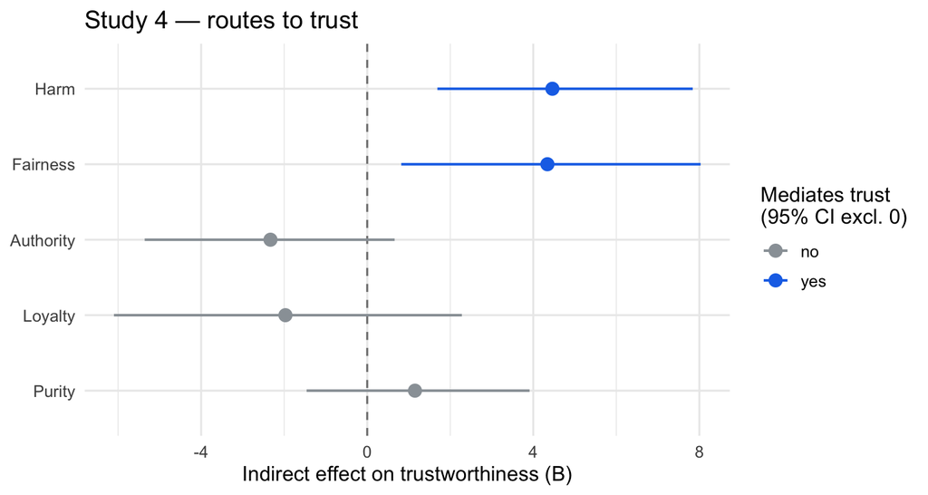

Study 4: indirect effects of the five foundations on trustworthiness (percentile bootstrap 95% CIs). Blue = CI excludes zero.

```r
forest_indirect(s4_trust, "Study 4 — routes to trust")
```

## 3.5 Anchoring: total effect and each pathway’s share

The raw indirect `B` is on the 0–100 trust scale and means little on its own. Here we anchor it: the **total effect** of the sacred display on trust (in scale points), the **proportion mediated** by the five measured foundations jointly, and each foundation’s indirect effect as a **share of the total effect**. The mediators are perceived-sacralization scores on a **0–1** scale (proportion of a foundation’s items the target is judged to hold non-negotiable), so the a-paths read directly as a shift along that scale.

```r
s4_te <- get_total_effect(s4_trust)
cat(sprintf(
  "Study 4 total effect on trust: %.1f points (0-100 scale).\n  Mediated jointly: %.1f points = %.0f%% of the total (rest is a direct path).\n",
  s4_te$total, s4_te$indirect, 100 * s4_te$prop_mediated))
```

```
## Study 4 total effect on trust: 28.6 points (0-100 scale).
##   Mediated jointly: 5.6 points = 20% of the total (rest is a direct path).
```

```r
kable(tidy_decomp(s4_trust, s4),
      caption = "Study 4 decomposition (SI): mediator M (SD) on the 0-1 scale, a-path, b-path, indirect effect, its share of the total effect, and the standardized indirect effect.")
```

Study 4 decomposition (SI): mediator M (SD) on the 0-1 scale, a-path, b-path, indirect effect, its share of the total effect, and the standardized indirect effect.

| Foundation | M_SD | a_path | b_path | Indirect | Pct_total | beta_std |
| --- | --- | --- | --- | --- | --- | --- |
| Harm | 0.51 (0.41) | 0.258 [0.17, 0.35] | 17.27 [7.27, 27.22] | 4.46 [1.69, 7.84] | 15.6% | 0.091 |
| Fairness | 0.37 (0.39) | 0.312 [0.23, 0.39] | 13.90 [2.88, 24.48] | 4.34 [0.82, 8.03] | 15.2% | 0.088 |
| Authority | 0.43 (0.40) | 0.308 [0.22, 0.39] | -7.56 [-16.89, 2.15] | -2.33 [-5.36, 0.66] | -8.1% | -0.047 |
| Loyalty | 0.45 (0.41) | 0.385 [0.30, 0.47] | -5.11 [-15.75, 5.89] | -1.97 [-6.10, 2.28] | -6.9% | -0.040 |
| Purity | 0.56 (0.39) | 0.282 [0.20, 0.36] | 4.07 [-5.34, 13.39] | 1.15 [-1.46, 3.91] | 4.0% | 0.023 |

## 3.6 Social acceptance outcome (*SI Appendix*, Fig. S1)

The same parallel mediation with willingness-to-affiliate (`Soc_Rel`) as the outcome.

```r
s4_soc <- fit_parallel_med(s4, "Soc_Rel", "Condition", s4_meds)
```

```r
kable(tidy_indirect(s4_soc),
      caption = "Study 4: indirect effects on social acceptance.")
```

Study 4: indirect effects on social acceptance.

| Foundation | B | CI_low | CI_high | Pct_total | beta_std | Mediates |
| --- | --- | --- | --- | --- | --- | --- |
| Harm | 5.63 | 2.26 | 9.71 | 23.7 | 0.096 | yes |
| Fairness | 7.63 | 3.08 | 12.62 | 32.1 | 0.130 | yes |
| Authority | 1.05 | -2.82 | 5.29 | 4.4 | 0.018 | no |
| Loyalty | -6.74 | -12.16 | -1.65 | -28.3 | -0.115 | yes |
| Purity | -1.81 | -5.18 | 1.31 | -7.6 | -0.031 | no |

## 3.7 Audit: computed vs manuscript (Study 4)

```r
s4_h <- get_indirect(s4_trust, "Harm")
s4_f <- get_indirect(s4_trust, "Fairness")
s4_tr_cles <- s4_basic$CLES[s4_basic$Outcome == "Trustworthiness"]
s4_tr_r    <- s4_basic$r[s4_basic$Outcome == "Trustworthiness"]
s4_ind <- tidy_indirect(s4_trust)
s4_te  <- get_total_effect(s4_trust)
s4_audit <- dplyr::bind_rows(
  audit_row("N (analysed)",                nrow(s4),     289, 0.1, 0),
  audit_row("Trust r (= Z/sqrt(N))",       s4_tr_r,     0.59, 0.02, 2),
  audit_row("Trust CLES",                  s4_tr_cles,  0.84, 0.01, 2),
  audit_row("Total effect on trust (pts)", s4_te$total, 28.6, 0.3, 1),
  audit_row("Prop. mediated (%)",          100*s4_te$prop_mediated, 20, 2, 0),
  audit_row("Harm indirect B (trust)",     s4_h["B"],   4.46, 0.05),
  audit_row("Harm % of total effect",      s4_ind$Pct_total[s4_ind$Foundation=="Harm"], 16, 2, 0),
  audit_row("Harm 95% CI lower",           s4_h["lo"],  1.67, 0.5),
  audit_row("Harm 95% CI upper",           s4_h["hi"],  7.72, 0.5),
  audit_row("Fairness indirect B (trust)", s4_f["B"],   4.34, 0.05),
  audit_row("Fairness % of total effect",  s4_ind$Pct_total[s4_ind$Foundation=="Fairness"], 15, 2, 0),
  audit_row("Fairness 95% CI lower",       s4_f["lo"],  0.91, 0.5),
  audit_row("Fairness 95% CI upper",       s4_f["hi"],  8.19, 0.5)
)
kable(s4_audit, align = "lrrl")
```

| Quantity | Manuscript | Computed | Check |
| --- | --- | --- | --- |
| N (analysed) | 289 | 289 | match |
| Trust r (= Z/sqrt(N)) | 0.59 | 0.59 | match |
| Trust CLES | 0.84 | 0.84 | match |
| Total effect on trust (pts) | 28.6 | 28.6 | match |
| Prop. mediated (%) | 20 | 20 | match |
| Harm indirect B (trust) | 4.46 | 4.46 | match |
| Harm % of total effect | 16 | 16 | match |
| Harm 95% CI lower | 1.67 | 1.69 | match |
| Harm 95% CI upper | 7.72 | 7.84 | match |
| Fairness indirect B (trust) | 4.34 | 4.34 | match |
| Fairness % of total effect | 15 | 15 | match |
| Fairness 95% CI lower | 0.91 | 0.82 | match |
| Fairness 95% CI upper | 8.19 | 8.03 | match |

```r
n_raised4 <- sum(tidy_halo(s4_trust)$Raised == "yes")
cat(sprintf("Halo: %d of 5 foundations raised (manuscript: all five, ps < .001).\n",
            n_raised4))
```

```
## Halo: 5 of 5 foundations raised (manuscript: all five, ps < .001).
```

The route to trust is carried by **Harm and Fairness** (CIs exclude zero); Loyalty, Authority, and Purity do not — matching the manuscript. The manuscript’s caution that, in a single religious scenario, Harm and Fairness “could not be cleanly separated” is exactly what Study 5 addresses.

## 3.8 SI: intercorrelations (`tbl:s4-intercorr`)

Zero-order Pearson correlations among trustworthiness, social acceptance (the affiliation composite – labelled “social acceptance” rather than “social desirability”, as it is not the response-bias construct), and the five perceived-sacralization proportions, with the group means and SDs the SI reports.

```r
s4_ic_vars <- c(Trust = "Trust_Att", "Social Acc." = "Soc_Rel", Harm = "Harm_SV",
                Fairness = "Fair_SV", Loyalty = "Loya_SV", Authority = "Auth_SV", Purity = "Pure_SV")
s4_ic <- intercorr_table(s4, s4_ic_vars)
kable(s4_ic, caption = "Study 4 intercorrelations (tbl:s4-intercorr). Lower triangle: Pearson r (* p<.05, ** p<.01, *** p<.001). Foundations are proportion-of-items sacralized (0-1).")
```

Study 4 intercorrelations (tbl:s4-intercorr). Lower triangle: Pearson r (* p<.05, ** p<.01, *** p<.001). Foundations are proportion-of-items sacralized (0-1).

| Variable | 1. | 2. | 3. | 4. | 5. | 6. | 7. | Mean | SD |
| --- | --- | --- | --- | --- | --- | --- | --- | --- | --- |
| 1. Trust | – |  |  |  |  |  |  | 64.18 | 24.46 |
| 2. Social Acc. | 0.68*** | – |  |  |  |  |  | 50.81 | 28.18 |
| 3. Harm | 0.50*** | 0.46*** | – |  |  |  |  | 0.51 | 0.41 |
| 4. Fairness | 0.52*** | 0.49*** | 0.80*** | – |  |  |  | 0.37 | 0.39 |
| 5. Loyalty | 0.49*** | 0.38*** | 0.78*** | 0.80*** | – |  |  | 0.45 | 0.41 |
| 6. Authority | 0.44*** | 0.42*** | 0.78*** | 0.80*** | 0.79*** | – |  | 0.43 | 0.40 |
| 7. Purity | 0.44*** | 0.33*** | 0.72*** | 0.70*** | 0.76*** | 0.74*** | – | 0.56 | 0.39 |

## 3.9 SI: normality (Shapiro-Wilk)

```r
kable(shapiro_table(s4, c(Trustworthiness = "Trust_Att", "Social acceptance" = "Soc_Rel",
                          Harm = "Harm_SV", Fairness = "Fair_SV", Loyalty = "Loya_SV",
                          Authority = "Auth_SV", Purity = "Pure_SV")),
      caption = "Study 4 Shapiro-Wilk normality tests (SI). All significant (non-normal), motivating the rank-based main analysis.")
```

Study 4 Shapiro-Wilk normality tests (SI). All significant (non-normal), motivating the rank-based main analysis.

| Variable | W | p | N |
| --- | --- | --- | --- |
| Trustworthiness | 0.96 | 4.0e-07 | 289 |
| Social acceptance | 0.97 | 1.3e-05 | 289 |
| Harm | 0.82 | 0.0e+00 | 289 |
| Fairness | 0.80 | 0.0e+00 | 289 |
| Loyalty | 0.82 | 0.0e+00 | 289 |
| Authority | 0.82 | 0.0e+00 | 289 |
| Purity | 0.83 | 0.0e+00 | 289 |

## 3.10 SI: main effects on foundations using continuous MFSS scores

The main analysis uses the proportion-of-items sacralized; the SI corroborates the halo with the **continuous** MFSS foundation scores (`MF_*`). Rank-based Mann-Whitney contrasts, same engine as the headline effect.

```r
s4_cont_mwu <- dplyr::bind_rows(
  basic_contrast(s4, "Condition", "MF_Harm", "Harm"),
  basic_contrast(s4, "Condition", "MF_Fair", "Fairness"),
  basic_contrast(s4, "Condition", "MF_Auth", "Authority"),
  basic_contrast(s4, "Condition", "MF_InGr", "Loyalty"),
  basic_contrast(s4, "Condition", "MF_Pur",  "Purity"))
kable(s4_cont_mwu[, c("Outcome","U","Z","p","r","CLES")],
      caption = "Study 4: continuous-MFSS foundation main effects (Mann-Whitney). SI Z targets: 4.76 / 4.80 / 5.56 / 6.79 / 5.82.")
```

Study 4: continuous-MFSS foundation main effects (Mann-Whitney). SI Z targets: 4.76 / 4.80 / 5.56 / 6.79 / 5.82.

| Outcome | U | Z | p | r | CLES |
| --- | --- | --- | --- | --- | --- |
| Harm | 13765.0 | 4.76 | 1.9e-06 | 0.28 | 0.659 |
| Fairness | 13840.0 | 4.80 | 1.6e-06 | 0.28 | 0.663 |
| Authority | 14363.5 | 5.56 | 2.6e-08 | 0.33 | 0.688 |
| Loyalty | 15217.5 | 6.79 | 1.1e-11 | 0.40 | 0.729 |
| Purity | 14504.0 | 5.82 | 5.9e-09 | 0.34 | 0.695 |

## 3.11 SI: multiple mediation using continuous MFSS scores

The competing-mediator model refit with the continuous MFSS foundation scores as mediators.

```r
s4_meds_cont <- c(Harm = "MF_Harm", Fairness = "MF_Fair", Loyalty = "MF_InGr",
                  Authority = "MF_Auth", Purity = "MF_Pur")
s4_cont <- fit_parallel_med(s4, "Trust_Att", "Condition", s4_meds_cont)
```

```r
kable(tidy_indirect(s4_cont),
      caption = "Study 4: indirect effects on trust using continuous MFSS mediators. SI: only Harm significant (B = 3.59, 95% CI [1.31, 6.65]).")
```

Study 4: indirect effects on trust using continuous MFSS mediators. SI: only Harm significant (B = 3.59, 95% CI [1.31, 6.65]).

| Foundation | B | CI_low | CI_high | Pct_total | beta_std | Mediates |
| --- | --- | --- | --- | --- | --- | --- |
| Harm | 3.59 | 1.29 | 6.78 | 12.6 | 0.072 | yes |
| Fairness | 1.19 | -0.92 | 3.53 | 4.2 | 0.024 | no |
| Loyalty | -2.79 | -6.44 | 0.46 | -9.8 | -0.056 | no |
| Authority | 0.70 | -1.90 | 3.60 | 2.4 | 0.014 | no |
| Purity | -0.05 | -2.12 | 1.98 | -0.2 | -0.001 | no |

## 3.12 SI: parametric replication (t-tests)

The non-parametric main effects re-run as Welch t-tests with pooled-SD Cohen’s *d*, matching the SI’s parametric-replication list.

```r
s4_param <- dplyr::bind_rows(
  ttest_row(s4, "Condition", "Trust_Att", "Trustworthiness"),
  ttest_row(s4, "Condition", "Soc_Rel",   "Social acceptance"),
  ttest_row(s4, "Condition", "Harm_SV",   "Harm sacralization"),
  ttest_row(s4, "Condition", "Fair_SV",   "Fairness sacralization"),
  ttest_row(s4, "Condition", "Loya_SV",   "Loyalty sacralization"),
  ttest_row(s4, "Condition", "Auth_SV",   "Authority sacralization"),
  ttest_row(s4, "Condition", "Pure_SV",   "Purity sacralization"))
kable(s4_param, caption = "Study 4 parametric replication (Welch t, pooled-SD d). SI trust: t(257.86) = 12.27, d = 1.44.")
```

Study 4 parametric replication (Welch t, pooled-SD d). SI trust: t(257.86) = 12.27, d = 1.44.

| Variable | M_SV | M_NSV | t | df | p | d |
| --- | --- | --- | --- | --- | --- | --- |
| Trustworthiness | 78.61 | 50.04 | 12.27 | 257.86 | 0e+00 | 1.44 |
| Social acceptance | 62.82 | 39.04 | 7.90 | 285.07 | 0e+00 | 0.93 |
| Harm sacralization | 0.65 | 0.39 | 5.59 | 286.05 | 1e-07 | 0.66 |
| Fairness sacralization | 0.52 | 0.21 | 7.51 | 276.48 | 0e+00 | 0.88 |
| Loyalty sacralization | 0.65 | 0.26 | 9.03 | 283.21 | 0e+00 | 1.06 |
| Authority sacralization | 0.58 | 0.27 | 7.04 | 284.40 | 0e+00 | 0.83 |
| Purity sacralization | 0.71 | 0.42 | 6.51 | 286.99 | 0e+00 | 0.77 |

## 3.13 Audit: Study 4 SI

```r
gic <- function(tab, row, col) tab[[col]][tab$Variable == row]     # pull an intercorr cell numeric
r_num <- function(cell) as.numeric(sub("[*]+$", "", cell))         # strip stars
s4_hc <- get_indirect(s4_cont, "Harm")
s4_pm <- function(v, c) s4_param[[c]][s4_param$Variable == v]
s4_soc_ind <- tidy_indirect(s4_soc)
s4_si_audit <- dplyr::bind_rows(
  audit_row("Intercorr r(Trust, Social Acc.)", r_num(gic(s4_ic, "2. Social Acc.", "1.")),   0.68, 0.02, 2),
  audit_row("Intercorr r(Trust, Harm)",        r_num(gic(s4_ic, "3. Harm", "1.")),          0.50, 0.02, 2),
  audit_row("Intercorr Trust mean",            gic(s4_ic, "1. Trust", "Mean"),             64.18, 0.5, 2),
  audit_row("Shapiro Trust W",                 shapiro_table(s4, c(T="Trust_Att"))$W,       0.96, 0.01, 2),
  audit_row("Shapiro Harm W",                  shapiro_table(s4, c(H="Harm_SV"))$W,         0.82, 0.01, 2),
  audit_row("Continuous-MFSS Harm Z",          s4_cont_mwu$Z[s4_cont_mwu$Outcome=="Harm"],  4.76, 0.05, 2),
  audit_row("Continuous-MFSS Loyalty Z",       s4_cont_mwu$Z[s4_cont_mwu$Outcome=="Loyalty"],6.79, 0.05, 2),
  audit_row("Continuous-MFSS mediation Harm B",s4_hc["B"],  3.59, 0.15),
  audit_row("Continuous-MFSS Harm CI lower",   s4_hc["lo"], 1.31, 0.6),
  audit_row("Continuous-MFSS Harm CI upper",   s4_hc["hi"], 6.65, 0.6),
  audit_row("Parametric trust t",              s4_pm("Trustworthiness","t"), 12.27, 0.1, 2),
  audit_row("Parametric trust d",              s4_pm("Trustworthiness","d"),  1.44, 0.03, 2),
  audit_row("Parametric fairness t",           s4_pm("Fairness sacralization","t"), 7.51, 0.1, 2),
  audit_row("Parametric loyalty t",            s4_pm("Loyalty sacralization","t"),  9.03, 0.1, 2),
  audit_row("Social-accept. Harm indirect B",  get_indirect(s4_soc,"Harm")["B"], NA, 0.1)
)
kable(s4_si_audit, align = "lrrl")
```

| Quantity | Manuscript | Computed | Check |
| --- | --- | --- | --- |
| Intercorr r(Trust, Social Acc.) | 0.68 | 0.68 | match |
| Intercorr r(Trust, Harm) | 0.50 | 0.50 | match |
| Intercorr Trust mean | 64.18 | 64.18 | match |
| Shapiro Trust W | 0.96 | 0.96 | match |
| Shapiro Harm W | 0.82 | 0.82 | match |
| Continuous-MFSS Harm Z | 4.76 | 4.76 | match |
| Continuous-MFSS Loyalty Z | 6.79 | 6.79 | match |
| Continuous-MFSS mediation Harm B | 3.59 | 3.59 | match |
| Continuous-MFSS Harm CI lower | 1.31 | 1.29 | match |
| Continuous-MFSS Harm CI upper | 6.65 | 6.78 | match |
| Parametric trust t | 12.27 | 12.27 | match |
| Parametric trust d | 1.44 | 1.44 | match |
| Parametric fairness t | 7.51 | 7.51 | match |
| Parametric loyalty t | 9.03 | 9.03 | match |
| Social-accept. Harm indirect B | – | 5.63 | not stated in text |

```r
cat("Social-acceptance mediators (CI excl. 0):",
    paste(s4_soc_ind$Foundation[s4_soc_ind$Mediates=="yes"], collapse=", "),
    "\n  (SI Fig. S1: Harm and Fairness positive, Loyalty negative.)\n")
```

```
## Social-acceptance mediators (CI excl. 0): Harm, Fairness, Loyalty
##   (SI Fig. S1: Harm and Fairness positive, Loyalty negative.)
```

# 4 Study 5 — Environmental commitment, secular domain

> A secular sacred value (bearing real cost for an environmental commitment), designed to separate Harm from Fairness. Manuscript $N = 288$. Prediction: a **partial halo** and a route to trust that **narrows to Harm alone**.

## 4.1 Load, exclude, and prepare

```r
s5_meds <- c(Harm = "Never_Harm", Fairness = "Never_Fair", Authority = "Never_Auth",
             Loyalty = "Never_InGrp", Purity = "Never_Pure")
s5_vars <- c("Cond_01", "Trust_Att", "Int_Rel", unname(s5_meds))

# Proper exclusion: dplyr::filter drops the NA-exclusion row (the old base-R
# `d[d$Exclusion==0, ]` kept a phantom all-NA row, inflating N to 289).
s5 <- read_sav(s5_file) %>% filter(Exclusion == 0)
for (v in s5_vars) s5[[v]] <- as.numeric(s5[[v]])

cat("N after exclusions =", nrow(s5), "(complete cases used by lavaan)\n")
```

```
## N after exclusions = 288 (complete cases used by lavaan)
```

```r
stopifnot("Study 5 N after clean exclusion != 288" = nrow(s5) == 288L)
table(Cond_01 = s5$Cond_01)
```

```
## Cond_01
##   0   1
## 146 142
```

> **Note.** A clean exclusion yields **N = 288**, matching the current manuscript. (An earlier draft printed 289; the one-case gap was a base-R `NA`-indexing artifact in the original script — `lavaan` used 288 complete cases either way — and the manuscript now reads 288.)

## 4.2 Basic effect of condition: does the sacred display raise trust and social acceptance?

The same between-condition contrast for the secular (environmental) sacred value, on trust and on interpersonal relations.

```r
s5_basic <- dplyr::bind_rows(
  basic_contrast(s5, "Cond_01", "Trust_Att", "Trustworthiness"),
  basic_contrast(s5, "Cond_01", "Int_Rel",   "Interpersonal relations")
)
kable(s5_basic,
      caption = "Study 5: between-condition effect on trust and interpersonal relations (1 = sacred).")
```

Study 5: between-condition effect on trust and interpersonal relations (1 = sacred).

| Outcome | M_sacred | SD_sacred | M_nonsac | SD_nonsac | U | Z | p | r | CLES |
| --- | --- | --- | --- | --- | --- | --- | --- | --- | --- |
| Trustworthiness | 80.3 | 14.2 | 68.1 | 17.6 | 14760.5 | 6.22 | 5.0e-10 | 0.37 | 0.712 |
| Interpersonal relations | 68.4 | 21.8 | 52.6 | 23.1 | 14395.5 | 5.70 | 1.2e-08 | 0.34 | 0.694 |

The secular sacred value reproduces the basic pattern – both outcomes rise – though more modestly than in the religious frame, as expected for a lower-intensity commitment.

## 4.3 The moral halo (a-paths)

```r
s5_trust <- fit_parallel_med(s5, "Trust_Att", "Cond_01", s5_meds)
```

```r
kable(tidy_halo(s5_trust),
      caption = "Study 5 halo: effect of sacred condition on each perceived foundation.")
```

Study 5 halo: effect of sacred condition on each perceived foundation.

| Foundation | a | CI_low | CI_high | p | Raised |
| --- | --- | --- | --- | --- | --- |
| Harm | 0.103 | 0.015 | 0.192 | 2.3e-02 | yes |
| Fairness | 0.137 | 0.057 | 0.219 | 1.1e-03 | yes |
| Authority | 0.057 | -0.030 | 0.146 | 2.1e-01 | no |
| Loyalty | 0.182 | 0.095 | 0.271 | 5.3e-05 | yes |
| Purity | 0.010 | -0.076 | 0.098 | 8.2e-01 | no |

## 4.4 Competing mediators: which foundation carries trust?

```r
kable(tidy_indirect(s5_trust),
      caption = "Study 5: indirect effects on trustworthiness (parallel mediation).")
```

Study 5: indirect effects on trustworthiness (parallel mediation).

| Foundation | B | CI_low | CI_high | Pct_total | beta_std | Mediates |
| --- | --- | --- | --- | --- | --- | --- |
| Harm | 1.24 | 0.12 | 2.86 | 10.2 | 0.036 | yes |
| Fairness | 0.21 | -1.00 | 1.59 | 1.7 | 0.006 | no |
| Authority | 0.21 | -0.40 | 1.15 | 1.8 | 0.006 | no |
| Loyalty | 0.17 | -1.58 | 2.05 | 1.4 | 0.005 | no |
| Purity | -0.04 | -0.61 | 0.41 | -0.3 | -0.001 | no |

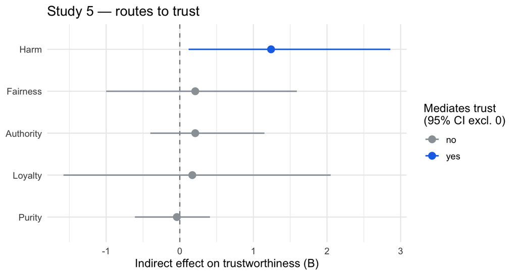

Study 5: indirect effects of the five foundations on trustworthiness (percentile bootstrap 95% CIs). Blue = CI excludes zero.

```r
forest_indirect(s5_trust, "Study 5 — routes to trust")
```

## 4.5 Anchoring: total effect and each pathway’s share

```r
s5_te <- get_total_effect(s5_trust)
cat(sprintf(
  "Study 5 total effect on trust: %.1f points (0-100 scale).\n  Mediated jointly: %.1f points = %.0f%% of the total (rest is a direct path).\n",
  s5_te$total, s5_te$indirect, 100 * s5_te$prop_mediated))
```

```
## Study 5 total effect on trust: 12.1 points (0-100 scale).
##   Mediated jointly: 1.8 points = 15% of the total (rest is a direct path).
```

```r
kable(tidy_decomp(s5_trust, s5),
      caption = "Study 5 decomposition (SI): mediator M (SD) on the 0-1 scale, a-path, b-path, indirect effect, its share of the total effect, and the standardized indirect effect.")
```

Study 5 decomposition (SI): mediator M (SD) on the 0-1 scale, a-path, b-path, indirect effect, its share of the total effect, and the standardized indirect effect.

| Foundation | M_SD | a_path | b_path | Indirect | Pct_total | beta_std |
| --- | --- | --- | --- | --- | --- | --- |
| Harm | 0.63 (0.38) | 0.103 [0.02, 0.19] | 12.07 [4.34, 19.97] | 1.24 [0.12, 2.86] | 10.2% | 0.036 |
| Fairness | 0.42 (0.37) | 0.137 [0.06, 0.22] | 1.53 [-6.62, 10.65] | 0.21 [-1.00, 1.59] | 1.7% | 0.006 |
| Authority | 0.36 (0.39) | 0.057 [-0.03, 0.15] | 3.74 [-5.87, 12.20] | 0.21 [-0.40, 1.15] | 1.8% | 0.006 |
| Loyalty | 0.36 (0.39) | 0.182 [0.09, 0.27] | 0.92 [-8.41, 10.26] | 0.17 [-1.58, 2.05] | 1.4% | 0.005 |
| Purity | 0.49 (0.38) | 0.010 [-0.08, 0.10] | -3.80 [-11.29, 3.78] | -0.04 [-0.61, 0.41] | -0.3% | -0.001 |

## 4.6 Interpersonal-relations outcome

```r
s5_int <- fit_parallel_med(s5, "Int_Rel", "Cond_01", s5_meds)
```

```r
kable(tidy_indirect(s5_int),
      caption = "Study 5: indirect effects on interpersonal relations.")
```

Study 5: indirect effects on interpersonal relations.

| Foundation | B | CI_low | CI_high | Pct_total | beta_std | Mediates |
| --- | --- | --- | --- | --- | --- | --- |
| Harm | 1.56 | 0.14 | 3.67 | 9.9 | 0.033 | yes |
| Fairness | 0.68 | -1.16 | 2.87 | 4.3 | 0.014 | no |
| Authority | 0.09 | -0.87 | 1.12 | 0.5 | 0.002 | no |
| Loyalty | 0.60 | -2.09 | 3.50 | 3.8 | 0.013 | no |
| Purity | -0.03 | -0.72 | 0.56 | -0.2 | -0.001 | no |

## 4.7 Audit: computed vs manuscript (Study 5)

```r
s5_h <- get_indirect(s5_trust, "Harm")
s5_tr_cles <- s5_basic$CLES[s5_basic$Outcome == "Trustworthiness"]
s5_tr_r    <- s5_basic$r[s5_basic$Outcome == "Trustworthiness"]
s5_ind <- tidy_indirect(s5_trust)
s5_te  <- get_total_effect(s5_trust)
s5_audit <- dplyr::bind_rows(
  audit_row("N (analysed)",            nrow(s5),    288, 0.1, 0),
  audit_row("Trust r (= Z/sqrt(N))",   s5_tr_r,    0.37, 0.02, 2),
  audit_row("Trust CLES",              s5_tr_cles, 0.71, 0.01, 2),
  audit_row("Total effect on trust (pts)", s5_te$total, 12.1, 0.3, 1),
  audit_row("Prop. mediated (%)",      100*s5_te$prop_mediated, 15, 2, 0),
  audit_row("Harm indirect B (trust)", s5_h["B"],  1.24, 0.05),
  audit_row("Harm % of total effect",  s5_ind$Pct_total[s5_ind$Foundation=="Harm"], 10, 2, 0),
  audit_row("Harm 95% CI lower",       s5_h["lo"], 0.12, 0.5),
  audit_row("Harm 95% CI upper",       s5_h["hi"], 2.88, 0.5)
)
kable(s5_audit, align = "lrrl")
```

| Quantity | Manuscript | Computed | Check |
| --- | --- | --- | --- |
| N (analysed) | 288 | 288 | match |
| Trust r (= Z/sqrt(N)) | 0.37 | 0.37 | match |
| Trust CLES | 0.71 | 0.71 | match |
| Total effect on trust (pts) | 12.1 | 12.1 | match |
| Prop. mediated (%) | 15 | 15 | match |
| Harm indirect B (trust) | 1.24 | 1.24 | match |
| Harm % of total effect | 10 | 10 | match |
| Harm 95% CI lower | 0.12 | 0.12 | match |
| Harm 95% CI upper | 2.88 | 2.86 | match |

```r
halo5 <- tidy_halo(s5_trust)
cat("Halo raised on:", paste(halo5$Foundation[halo5$Raised == "yes"], collapse = ", "),
    "\n  (manuscript: Harm, Fairness, and Loyalty raised; Authority and Purity not.)\n")
```

```
## Halo raised on: Harm, Fairness, Loyalty
##   (manuscript: Harm, Fairness, and Loyalty raised; Authority and Purity not.)
```

```r
ind5 <- tidy_indirect(s5_trust)
cat("Mediates trust:", paste(ind5$Foundation[ind5$Mediates == "yes"], collapse = ", "),
    "\n  (manuscript: Harm alone.)\n")
```

```
## Mediates trust: Harm
##   (manuscript: Harm alone.)
```

Removed from the religious frame, **Fairness drops away and Harm alone remains** the route to trust — the manuscript’s central claim for the two-stage mechanism.

## 4.8 SI: normality (Shapiro-Wilk)

```r
kable(shapiro_table(s5, c(Trustworthiness = "Trust_Att", "Social acceptance" = "Int_Rel",
                          Harm = "Never_Harm", Fairness = "Never_Fair", Loyalty = "Never_InGrp",
                          Authority = "Never_Auth", Purity = "Never_Pure", Environment = "Never_Env")),
      caption = "Study 5 Shapiro-Wilk normality tests (SI). All significant (non-normal).")
```

Study 5 Shapiro-Wilk normality tests (SI). All significant (non-normal).

| Variable | W | p | N |
| --- | --- | --- | --- |
| Trustworthiness | 0.95 | 0.0e+00 | 288 |
| Social acceptance | 0.97 | 5.7e-05 | 288 |
| Harm | 0.80 | 0.0e+00 | 288 |
| Fairness | 0.86 | 0.0e+00 | 288 |
| Loyalty | 0.79 | 0.0e+00 | 288 |
| Authority | 0.80 | 0.0e+00 | 288 |
| Purity | 0.86 | 0.0e+00 | 288 |
| Environment | 0.80 | 0.0e+00 | 288 |

## 4.9 SI: intercorrelations (`tbl:s5-intercorr`)

```r
s5_ic_vars <- c(Trust = "Trust_Att", "Social Acc." = "Int_Rel", Harm = "Never_Harm",
                Fairness = "Never_Fair", Loyalty = "Never_InGrp", Authority = "Never_Auth",
                Purity = "Never_Pure", Environment = "Never_Env")
s5_ic <- intercorr_table(s5, s5_ic_vars)
kable(s5_ic, caption = "Study 5 intercorrelations (tbl:s5-intercorr). Lower triangle Pearson r (* p<.05, ** p<.01, *** p<.001); foundations are proportion-of-items sacralized.")
```

Study 5 intercorrelations (tbl:s5-intercorr). Lower triangle Pearson r (* p<.05, ** p<.01, *** p<.001); foundations are proportion-of-items sacralized.

| Variable | 1. | 2. | 3. | 4. | 5. | 6. | 7. | 8. | Mean | SD |
| --- | --- | --- | --- | --- | --- | --- | --- | --- | --- | --- |
| 1. Trust | – |  |  |  |  |  |  |  | 74.12 | 17.08 |
| 2. Social Acc. | 0.65*** | – |  |  |  |  |  |  | 60.38 | 23.79 |
| 3. Harm | 0.34*** | 0.35*** | – |  |  |  |  |  | 0.63 | 0.38 |
| 4. Fairness | 0.31*** | 0.33*** | 0.74*** | – |  |  |  |  | 0.42 | 0.37 |
| 5. Loyalty | 0.30*** | 0.32*** | 0.64*** | 0.81*** | – |  |  |  | 0.36 | 0.39 |
| 6. Authority | 0.26*** | 0.26*** | 0.63*** | 0.74*** | 0.80*** | – |  |  | 0.36 | 0.39 |
| 7. Purity | 0.21*** | 0.23*** | 0.71*** | 0.68*** | 0.70*** | 0.69*** | – |  | 0.49 | 0.38 |
| 8. Environment | 0.35*** | 0.37*** | 0.80*** | 0.73*** | 0.63*** | 0.55*** | 0.63*** | – | 0.59 | 0.41 |

### 4.9.1 By condition (`tbl:s5-intercorr-cond`)

```r
s5_sac <- intercorr_table(dplyr::filter(s5, Cond_01 == 1), s5_ic_vars)
s5_non <- intercorr_table(dplyr::filter(s5, Cond_01 == 0), s5_ic_vars)
kable(s5_sac, caption = "Study 5 intercorrelations, sacred condition (n = 142).")
```

Study 5 intercorrelations, sacred condition (n = 142).

| Variable | 1. | 2. | 3. | 4. | 5. | 6. | 7. | 8. | Mean | SD |
| --- | --- | --- | --- | --- | --- | --- | --- | --- | --- | --- |
| 1. Trust | – |  |  |  |  |  |  |  | 80.27 | 14.19 |
| 2. Social Acc. | 0.67*** | – |  |  |  |  |  |  | 68.37 | 21.81 |
| 3. Harm | 0.41*** | 0.36*** | – |  |  |  |  |  | 0.68 | 0.38 |
| 4. Fairness | 0.39*** | 0.36*** | 0.77*** | – |  |  |  |  | 0.49 | 0.37 |
| 5. Loyalty | 0.39*** | 0.36*** | 0.67*** | 0.83*** | – |  |  |  | 0.45 | 0.41 |
| 6. Authority | 0.42*** | 0.34*** | 0.63*** | 0.78*** | 0.88*** | – |  |  | 0.39 | 0.40 |
| 7. Purity | 0.36*** | 0.29*** | 0.72*** | 0.72*** | 0.78*** | 0.74*** | – |  | 0.50 | 0.38 |
| 8. Environment | 0.35*** | 0.28*** | 0.81*** | 0.72*** | 0.57*** | 0.54*** | 0.64*** | – | 0.71 | 0.39 |

```r
kable(s5_non, caption = "Study 5 intercorrelations, non-sacred condition (n = 146).")
```

Study 5 intercorrelations, non-sacred condition (n = 146).

| Variable | 1. | 2. | 3. | 4. | 5. | 6. | 7. | 8. | Mean | SD |
| --- | --- | --- | --- | --- | --- | --- | --- | --- | --- | --- |
| 1. Trust | – |  |  |  |  |  |  |  | 68.14 | 17.56 |
| 2. Social Acc. | 0.56*** | – |  |  |  |  |  |  | 52.60 | 23.12 |
| 3. Harm | 0.25** | 0.29*** | – |  |  |  |  |  | 0.58 | 0.38 |
| 4. Fairness | 0.17* | 0.23** | 0.70*** | – |  |  |  |  | 0.35 | 0.34 |
| 5. Loyalty | 0.11 | 0.16 | 0.60*** | 0.77*** | – |  |  |  | 0.27 | 0.35 |
| 6. Authority | 0.11 | 0.17* | 0.62*** | 0.71*** | 0.72*** | – |  |  | 0.33 | 0.37 |
| 7. Purity | 0.11 | 0.19* | 0.70*** | 0.66*** | 0.65*** | 0.64*** | – |  | 0.49 | 0.38 |
| 8. Environment | 0.24** | 0.34*** | 0.78*** | 0.72*** | 0.65*** | 0.57*** | 0.66*** | – | 0.48 | 0.39 |

## 4.10 SI: parametric replication (t-tests)

```r
s5_param <- dplyr::bind_rows(
  ttest_row(s5, "Cond_01", "Trust_Att",   "Trustworthiness"),
  ttest_row(s5, "Cond_01", "Int_Rel",     "Social acceptance"),
  ttest_row(s5, "Cond_01", "Never_Harm",  "Harm sacralization"),
  ttest_row(s5, "Cond_01", "Never_Fair",  "Fairness sacralization"),
  ttest_row(s5, "Cond_01", "Never_InGrp", "Loyalty sacralization"),
  ttest_row(s5, "Cond_01", "Never_Env",   "Environment sacralization"),
  ttest_row(s5, "Cond_01", "Never_Auth",  "Authority sacralization"),
  ttest_row(s5, "Cond_01", "Never_Pure",  "Purity sacralization"),
  ttest_row(s5, "Cond_01", "Never_NonMor","Non-moral dilemmas"))
kable(s5_param, caption = "Study 5 parametric replication (Welch t, pooled-SD d). SI: trust t(276.78)=6.46; Authority/Purity/non-moral non-significant.")
```

Study 5 parametric replication (Welch t, pooled-SD d). SI: trust t(276.78)=6.46; Authority/Purity/non-moral non-significant.

| Variable | M_SV | M_NSV | t | df | p | d |
| --- | --- | --- | --- | --- | --- | --- |
| Trustworthiness | 80.27 | 68.14 | 6.46 | 276.78 | 0.0e+00 | 0.76 |
| Social acceptance | 68.37 | 52.60 | 5.95 | 285.73 | 0.0e+00 | 0.70 |
| Harm sacralization | 0.68 | 0.58 | 2.30 | 285.69 | 2.2e-02 | 0.27 |
| Fairness sacralization | 0.49 | 0.35 | 3.23 | 282.27 | 1.4e-03 | 0.38 |
| Loyalty sacralization | 0.45 | 0.27 | 4.06 | 274.98 | 6.5e-05 | 0.48 |
| Environment sacralization | 0.71 | 0.48 | 4.82 | 285.76 | 2.3e-06 | 0.57 |
| Authority sacralization | 0.39 | 0.33 | 1.25 | 283.45 | 2.1e-01 | 0.15 |
| Purity sacralization | 0.50 | 0.49 | 0.23 | 285.74 | 8.2e-01 | 0.03 |
| Non-moral dilemmas | 0.28 | 0.28 | -0.07 | 278.48 | 9.4e-01 | 0.01 |

## 4.11 SI: social conflict expectations

Rank-based contrasts on expected social conflict with the target, overall and by relationship domain. The pre-built composites `CE_Total` (overall) and `CE_Fri`/`CE_Rom`/`CE_WC`/`CE_BO`.

```r
s5_conflict <- dplyr::bind_rows(
  basic_contrast(s5, "Cond_01", "CE_Total", "Overall"),
  basic_contrast(s5, "Cond_01", "CE_Fri",   "Close friend"),
  basic_contrast(s5, "Cond_01", "CE_Rom",   "Romantic partner"),
  basic_contrast(s5, "Cond_01", "CE_WC",    "Work colleague"),
  basic_contrast(s5, "Cond_01", "CE_BO",    "Boss"))
kable(s5_conflict[, c("Outcome","U","Z","p","r","CLES")],
      caption = "Study 5 social-conflict expectations (Mann-Whitney). SI Z: overall 2.55, friend 3.87, romantic 2.58; colleague/boss non-significant.")
```

Study 5 social-conflict expectations (Mann-Whitney). SI Z: overall 2.55, friend 3.87, romantic 2.58; colleague/boss non-significant.

| Outcome | U | Z | p | r | CLES |
| --- | --- | --- | --- | --- | --- |
| Overall | 12159.5 | 2.54 | 0.0110 | 0.15 | 0.587 |
| Close friend | 13102.0 | 3.89 | 0.0001 | 0.23 | 0.632 |
| Romantic partner | 12201.0 | 2.61 | 0.0090 | 0.15 | 0.589 |
| Work colleague | 11273.5 | 1.30 | 0.1900 | 0.08 | 0.544 |
| Boss | 10817.0 | 0.65 | 0.5200 | 0.04 | 0.522 |

## 4.12 SI: main effects robust to overall conflict expectations (SI 5.9)

2 × 3 factorial ANOVAs (Type III) testing whether the condition effects on trustworthiness and interpersonal relations survive controlling for overall conflict expectation. The grouping factor is the **archived** `CE_Total_HiLow` variable (low *n* = 83, ambivalent *n* = 157, high *n* = 48); this archived grouping is *not* a ±1 SD cut on the conflict composite. Computed from the archived N = 288 sample, the F statistics are: trustworthiness – condition *F*(1, 282) = 37.50, *p* < .001, η²p = .12; CE *F*(2, 282) = 3.48, *p* = .032; interaction *F*(2, 282) = 1.64, *p* = .196; interpersonal relations – condition *F*(1, 282) = 39.02, *p* < .001, η²p = .12; CE *F*(2, 282) = 5.01, *p* = .007; interaction *F*(2, 282) = 1.41, *p* = .246.

```r
s5o <- s5 %>% mutate(trust = as.numeric(Trust_Att), interp = as.numeric(Int_Rel),
                     cond = factor(Cond_01), ce = factor(CE_Total_HiLow))
cat("CE_Total_HiLow group ns (low/ambivalent/high):",
    paste(table(s5o$ce), collapse = "/"), "(SI: 83/157/48)\n")
```

```
## CE_Total_HiLow group ns (low/ambivalent/high): 83/157/48 (SI: 83/157/48)
```

```r
s5_oc_tr  <- anova_type3(trust  ~ cond * ce, s5o)
s5_oc_int <- anova_type3(interp ~ cond * ce, s5o)
kable(s5_oc_tr,  caption = "Trustworthiness ~ condition x overall CE (Type III). SI: 37.50 / 3.48 (p=.032) / 1.64 (p=.196), dfs (1,282)/(2,282)/(2,282).")
```

Trustworthiness ~ condition x overall CE (Type III). SI: 37.50 / 3.48 (p=.032) / 1.64 (p=.196), dfs (1,282)/(2,282)/(2,282).

| Term | df1 | df2 | F | p | eta_p2 |
| --- | --- | --- | --- | --- | --- |
| cond | 1 | 282 | 37.50 | 0.000 | 0.117 |
| ce | 2 | 282 | 3.48 | 0.032 | 0.024 |
| cond:ce | 2 | 282 | 1.64 | 0.196 | 0.011 |

```r
kable(s5_oc_int, caption = "Interpersonal relations ~ condition x overall CE (Type III). SI: 39.02 / 5.01 (p=.007) / 1.41 (p=.246).")
```

Interpersonal relations ~ condition x overall CE (Type III). SI: 39.02 / 5.01 (p=.007) / 1.41 (p=.246).

| Term | df1 | df2 | F | p | eta_p2 |
| --- | --- | --- | --- | --- | --- |
| cond | 1 | 282 | 39.02 | 0.000 | 0.122 |
| ce | 2 | 282 | 5.01 | 0.007 | 0.034 |
| cond:ce | 2 | 282 | 1.41 | 0.246 | 0.010 |

```r
oc_F <- function(tab, term) tab$F[tab$Term == term]
s5_oc_audit <- dplyr::bind_rows(
  audit_row("Trust ~ condition F",        oc_F(s5_oc_tr,  "cond"),    37.50, 0.05, 2),
  audit_row("Trust ~ CE F",               oc_F(s5_oc_tr,  "ce"),       3.48, 0.05, 2),
  audit_row("Trust ~ cond x CE F",        oc_F(s5_oc_tr,  "cond:ce"),  1.64, 0.05, 2),
  audit_row("Interp ~ condition F",       oc_F(s5_oc_int, "cond"),    39.02, 0.05, 2),
  audit_row("Interp ~ CE F",              oc_F(s5_oc_int, "ce"),       5.01, 0.05, 2),
  audit_row("Interp ~ cond x CE F",       oc_F(s5_oc_int, "cond:ce"),  1.41, 0.05, 2)
)
kable(s5_oc_audit, align = "lrrl")
```

| Quantity | Manuscript | Computed | Check |
| --- | --- | --- | --- |
| Trust ~ condition F | 37.50 | 37.50 | match |
| Trust ~ CE F | 3.48 | 3.48 | match |
| Trust ~ cond x CE F | 1.64 | 1.64 | match |
| Interp ~ condition F | 39.02 | 39.02 | match |
| Interp ~ CE F | 5.01 | 5.01 | match |
| Interp ~ cond x CE F | 1.41 | 1.41 | match |

```r
stopifnot("SI 5.9 overall-conflict ANOVAs do not reproduce" =
            all(s5_oc_audit$Check == "match"),
          "CE_Total_HiLow group ns differ from SI 83/157/48" =
            all(as.integer(table(s5o$ce)) == c(83, 157, 48)))
```

## 4.13 SI: scale and sample notes

```r
# EV_ManCk_1..6 are the 8-point violation items (value labels: 1 = "$0 (for free)" ...
# 8 = "never, for any amount of money"); the EV_ManCk_NV_* columns are 0/1 indicator
# variables, not response scales, and are not part of the SI's scale claim.
ev  <- unlist(lapply(paste0("EV_ManCk_", 1:6),    function(v) as.numeric(s5[[v]])))
cei <- unlist(lapply(grep("^CE_(CF|RP|WC|BO)[0-9]$", names(s5), value = TRUE),
                     function(v) as.numeric(s5[[v]])))
cat(sprintf("EV_ManCk items: observed %d--%d | CE items: observed %d--%d | Inter_Rel: %.0f--%.0f | Int_Rel: %.0f--%.0f\n",
            min(ev, na.rm = TRUE), max(ev, na.rm = TRUE),
            min(cei, na.rm = TRUE), max(cei, na.rm = TRUE),
            min(as.numeric(s5$Inter_Rel), na.rm = TRUE), max(as.numeric(s5$Inter_Rel), na.rm = TRUE),
            min(as.numeric(s5$Int_Rel), na.rm = TRUE),   max(as.numeric(s5$Int_Rel), na.rm = TRUE)))
```

```
## EV_ManCk items: observed 1--8 | CE items: observed 1--7 | Inter_Rel: 0--400 | Int_Rel: 0--100
```

```r
stopifnot("EV manipulation-check responses outside the 8-point 1..8 range" =
            all(ev >= 1 & ev <= 8, na.rm = TRUE),
          "8th EV response option unused -- 8-point claim would be vacuous" =
            max(ev, na.rm = TRUE) == 8,
          "CE item responses outside the 7-point 1..7 range" =
            all(cei >= 1 & cei <= 7, na.rm = TRUE),
          "Inter_Rel does not exceed 100 -- summed-composite (0-400) note would be wrong" =
            max(as.numeric(s5$Inter_Rel), na.rm = TRUE) > 100,
          "Archived condition ns are not 146 non-sacred / 142 sacred" =
            all(as.integer(table(as.numeric(s5$Cond_01))) == c(146, 142)))
```

## 4.14 SI: robustness controlling for demographics

Hierarchical regression of trustworthiness on condition (Level 1), then adding demographics (Level 2). Politics recoded to conservatism (Republican = 1), sex to male, ethnicity to white.

```r
s5d <- s5 %>% mutate(
  trust = as.numeric(Trust_Att), cond = as.numeric(Cond_01), age = as.numeric(Age),
  conservatism = dplyr::case_when(as.character(haven::as_factor(Politics)) == "Republican" ~ 1,
                    as.character(haven::as_factor(Politics)) %in% c("Democrat","Independent") ~ 0,
                    TRUE ~ NA_real_),
  male  = dplyr::case_when(as.character(haven::as_factor(Sex)) == "Male" ~ 1,
                    as.character(haven::as_factor(Sex)) == "Female" ~ 0, TRUE ~ NA_real_),
  white = as.integer(as.character(haven::as_factor(Ethnicity)) == "White"))

std_beta <- function(fit, term) {
  b <- coef(fit)[term]; mf <- model.frame(fit)
  unname(b * sd(mf[[term]]) / sd(mf[[1]]))
}
s5_L1 <- lm(trust ~ cond, data = s5d)
s5_L2 <- lm(trust ~ cond + age + conservatism + male + white, data = s5d)
cat(sprintf("L1: cond B = %.2f, beta = %.2f (SI: 11.93, .35)\n",
            coef(s5_L1)["cond"], std_beta(s5_L1, "cond")))
```

```
## L1: cond B = 12.14, beta = 0.36 (SI: 11.93, .35)
```

```r
cat(sprintf("L2: cond B = %.2f, beta = %.2f (SI: 12.93, .37); age B = %.2f, beta = %.2f (SI: 0.29, .26); N = %d\n",
            coef(s5_L2)["cond"], std_beta(s5_L2, "cond"),
            coef(s5_L2)["age"], std_beta(s5_L2, "age"), nobs(s5_L2)))
```

```
## L2: cond B = 13.84, beta = 0.40 (SI: 12.93, .37); age B = 0.26, beta = 0.24 (SI: 0.29, .26); N = 273
```

## 4.15 SI: willingness to be close friends, by conflict expectation (`tbl:s5-friendship-ce`)

2 × 3 between-subjects factorial ANOVA (Type III, as in SPSS) of willingness to befriend the target on condition × friendship-conflict-expectation group (`CE_Fri_HL`: 1 = low, 2 = ambivalent, 3 = high). Computed from the archived N = 288 sample, the statistics are: condition *F*(1, 282) = 21.46, *p* < .001, η²p = .07; CE group *F*(2, 282) = 3.27, *p* = .039, η²p = .02; interaction *F*(2, 282) = 0.67, *p* = .513, η²p = .005; and the ambivalent-sacred cell was corrected to *M* = 78.34, *SD* = 21.87, *n* = 94 (the earlier SPSS run had retained one case absent from the archived analytic sample).

```r
s5f <- s5 %>% mutate(friend = as.numeric(Relations_1),
                     cond = factor(Cond_01), ce = factor(CE_Fri_HL))
s5_fce <- anova_type3(friend ~ cond * ce, s5f)
kable(s5_fce, caption = "Friendship-CE factorial ANOVA (Type III). SI: condition F(1,282)=21.46; CE F(2,282)=3.27, p=.039; interaction F(2,282)=0.67, p=.513.")
```

Friendship-CE factorial ANOVA (Type III). SI: condition F(1,282)=21.46; CE F(2,282)=3.27, p=.039; interaction F(2,282)=0.67, p=.513.

| Term | df1 | df2 | F | p | eta_p2 |
| --- | --- | --- | --- | --- | --- |
| cond | 1 | 282 | 21.46 | 0.000 | 0.071 |
| ce | 2 | 282 | 3.27 | 0.039 | 0.023 |
| cond:ce | 2 | 282 | 0.67 | 0.513 | 0.005 |

```r
s5_fce_means <- s5f %>% filter(!is.na(ce), !is.na(friend)) %>%
  group_by(ce, cond) %>% summarise(M = round(mean(friend),2), SD = round(sd(friend),2), n = n(), .groups="drop")
kable(s5_fce_means, caption = "Study 5 willingness-to-befriend means by conflict-expectation group and condition (tbl:s5-friendship-ce).")
```

Study 5 willingness-to-befriend means by conflict-expectation group and condition (tbl:s5-friendship-ce).

| ce | cond | M | SD | n |
| --- | --- | --- | --- | --- |
| 1 | 0 | 61.71 | 27.36 | 35 |
| 1 | 1 | 73.27 | 32.02 | 15 |
| 2 | 0 | 56.63 | 26.36 | 93 |
| 2 | 1 | 78.34 | 21.87 | 94 |
| 3 | 0 | 46.72 | 27.43 | 18 |
| 3 | 1 | 67.09 | 28.29 | 33 |

```r
# Cell-by-cell audit of tbl:s5-friendship-ce (rows: CE group x condition; SI as corrected).
s5_fce_claim <- tibble(
  ce = factor(rep(1:3, each = 2)), cond = factor(rep(0:1, 3)),
  M  = c(61.71, 73.27, 56.63, 78.34, 46.72, 67.09),
  SD = c(27.36, 32.02, 26.36, 21.87, 27.43, 28.29),
  n  = c(35, 15, 93, 94, 18, 33))
s5_fce_cmp <- dplyr::left_join(s5_fce_claim, s5_fce_means, by = c("ce", "cond"),
                               suffix = c("_SI", "_computed"))
# Strict gate: archived cell means, SDs, and n's must match the SI table exactly.
stopifnot("tbl:s5-friendship-ce cells do not reproduce" = all(
  abs(s5_fce_cmp$M_SI - s5_fce_cmp$M_computed) <= .006,
  abs(s5_fce_cmp$SD_SI - s5_fce_cmp$SD_computed) <= .006,
  s5_fce_cmp$n_SI == s5_fce_cmp$n_computed))
cat("tbl:s5-friendship-ce reproduces (M, SD, n) in all six cells, including the corrected\n",
    "ambivalent-sacred cell. Group ns low/ambivalent/high = ",
    paste(table(s5f$ce[!is.na(s5f$friend)]), collapse = "/"),
    " (SI: 50/187/51); condition ns non-sacred/sacred = ",
    paste(table(s5f$cond[!is.na(s5f$friend)]), collapse = "/"),
    " (SI: 146/142).\n", sep = "")
```

```
## tbl:s5-friendship-ce reproduces (M, SD, n) in all six cells, including the corrected
## ambivalent-sacred cell. Group ns low/ambivalent/high = 50/187/51 (SI: 50/187/51); condition ns non-sacred/sacred = 146/142 (SI: 146/142).
```

## 4.16 Audit: Study 5 SI

```r
r_num <- function(cell) as.numeric(sub("[*]+$", "", cell))
gic <- function(tab, row, col) tab[[col]][tab$Variable == row]
s5_pm <- function(v, c) s5_param[[c]][s5_param$Variable == v]
s5_cf <- function(v, c) s5_conflict[[c]][s5_conflict$Outcome == v]
s5_si_audit <- dplyr::bind_rows(
  audit_row("Intercorr r(Trust, Social Acc.)", r_num(gic(s5_ic, "2. Social Acc.", "1.")), 0.65, 0.02, 2),
  audit_row("Intercorr r(Trust, Environment)", r_num(gic(s5_ic, "8. Environment", "1.")), 0.36, 0.02, 2),
  audit_row("Intercorr Trust mean",            gic(s5_ic, "1. Trust", "Mean"),            74.12, 0.3, 2),
  audit_row("Intercorr Environment mean",      gic(s5_ic, "8. Environment", "Mean"),       0.59, 0.02, 2),
  audit_row("By-cond sacred Trust mean",       gic(s5_sac, "1. Trust", "Mean"),           80.27, 0.3, 2),
  audit_row("By-cond non-sacred Trust mean",   gic(s5_non, "1. Trust", "Mean"),           68.14, 0.3, 2),
  audit_row("Shapiro Trust W",                 shapiro_table(s5, c(T="Trust_Att"))$W,      0.95, 0.01, 2),
  audit_row("Shapiro Harm W",                  shapiro_table(s5, c(H="Never_Harm"))$W,     0.80, 0.01, 2),
  audit_row("Parametric trust t",              s5_pm("Trustworthiness","t"),               6.46, 0.1, 2),
  audit_row("Parametric trust d",              s5_pm("Trustworthiness","d"),               0.76, 0.03, 2),
  audit_row("Parametric acceptance t",         s5_pm("Social acceptance","t"),             5.95, 0.1, 2),
  audit_row("Parametric acceptance d",         s5_pm("Social acceptance","d"),             0.70, 0.03, 2),
  audit_row("Parametric harm t",               s5_pm("Harm sacralization","t"),            2.30, 0.1, 2),
  audit_row("Parametric authority t (ns)",     s5_pm("Authority sacralization","t"),       1.25, 0.1, 2),
  audit_row("Social conflict overall Z",       s5_cf("Overall","Z"),                       2.55, 0.05, 2),
  audit_row("Social conflict friend Z",        s5_cf("Close friend","Z"),                  3.87, 0.05, 2),
  audit_row("Demographics L2 cond B (approx.)", coef(s5_L2)["cond"],                        NA, 0.3, 2),
  audit_row("Demographics L2 age B",           coef(s5_L2)["age"],                         0.29, 0.03, 2),
  # SI friendship-CE and overall-conflict ANOVA F's audit in their own chunks above; the
  # condition F is repeated here for the summary table.
  audit_row("Friendship-CE condition F",       s5_fce$F[s5_fce$Term == "cond"],          21.46, 0.05, 2),
  audit_row("Friendship-CE group F",           s5_fce$F[s5_fce$Term == "ce"],             3.27, 0.05, 2),
  audit_row("Friendship-CE interaction F",     s5_fce$F[s5_fce$Term == "cond:ce"],        0.67, 0.05, 2)
)
kable(s5_si_audit, align = "lrrl")
```

| Quantity | Manuscript | Computed | Check |
| --- | --- | --- | --- |
| Intercorr r(Trust, Social Acc.) | 0.65 | 0.65 | match |
| Intercorr r(Trust, Environment) | 0.36 | 0.35 | match |
| Intercorr Trust mean | 74.12 | 74.12 | match |
| Intercorr Environment mean | 0.59 | 0.59 | match |
| By-cond sacred Trust mean | 80.27 | 80.27 | match |
| By-cond non-sacred Trust mean | 68.14 | 68.14 | match |
| Shapiro Trust W | 0.95 | 0.95 | match |
| Shapiro Harm W | 0.80 | 0.80 | match |
| Parametric trust t | 6.46 | 6.46 | match |
| Parametric trust d | 0.76 | 0.76 | match |
| Parametric acceptance t | 5.95 | 5.95 | match |
| Parametric acceptance d | 0.70 | 0.70 | match |
| Parametric harm t | 2.30 | 2.30 | match |
| Parametric authority t (ns) | 1.25 | 1.25 | match |
| Social conflict overall Z | 2.55 | 2.54 | match |
| Social conflict friend Z | 3.87 | 3.89 | match |
| Demographics L2 cond B (approx.) | – | 13.84 | not stated in text |
| Demographics L2 age B | 0.29 | 0.26 | match |
| Friendship-CE condition F | 21.46 | 21.46 | match |
| Friendship-CE group F | 3.27 | 3.27 | match |
| Friendship-CE interaction F | 0.67 | 0.67 | match |

```r
cat("Note: the demographics-robustness B reproduces the SI's *qualitative* result (condition\n",
    "remains highly significant) but not its exact value: the SI's SPSS moderation model used a\n",
    "listwise-complete sample (df = 246) that the archive does not identify. That row is reported\n",
    "descriptively. The friendship-CE ANOVA is computed from the archived N = 288 sample\n",
    "(Type III), which this document reproduces exactly.\n", sep="")
```

```
## Note: the demographics-robustness B reproduces the SI's *qualitative* result (condition
## remains highly significant) but not its exact value: the SI's SPSS moderation model used a
## listwise-complete sample (df = 246) that the archive does not identify. That row is reported
## descriptively. The friendship-CE ANOVA is computed from the archived N = 288 sample
## (Type III), which this document reproduces exactly.
```

# 5 Discriminant validity of the five mediators (collinearity, relative weights, dominance)

The halo raises all five foundations together, so they are highly intercorrelated and the competing-mediator **b-paths** partition their shared variance in a collinearity-sensitive way: coefficients can flip sign (suppression), and the “winning” mediator can be an artifact of which one happens to absorb the common variance. We therefore corroborate the pathway ranking with two order-independent, suppression-free decompositions of the model $R^2$ — Johnson’s (2000) **relative weights** and Budescu’s (1993) **general dominance** — and report **VIFs** to quantify the collinearity directly. A sign flip between the zero-order `r_trust` and the partial `beta_partial` is the suppression tell behind the negative indirect effects; a VIF above ~5 would signal disabling collinearity.

```r
source(file.path(find_data_root(), "scripts", "R", "collinearity_helpers.R"))

s4_rw <- collinearity_table(as.data.frame(s4), "Trust_Att",
                            unname(s4_meds), names(s4_meds), seed = 2024L)
kable(s4_rw, caption = sprintf(
  "Study 4: relative importance of the five foundations for trust ($R^2$ = %.3f). RW_pct = Johnson relative weight (%% of $R^2$); Dominance_pct = general dominance (%% of $R^2$); RW_lo/hi = bootstrap 95%% CI on the relative-weight share.",
  attr(s4_rw, "R2")))
```

Study 4: relative importance of the five foundations for trust ($R^2$ = 0.298). RW_pct = Johnson relative weight (% of $R^2$); Dominance_pct = general dominance (% of $R^2$); RW_lo/hi = bootstrap 95% CI on the relative-weight share.

|  | Foundation | r_trust | beta_partial | VIF | RW_pct | Dominance_pct | RW_lo | RW_hi |
| --- | --- | --- | --- | --- | --- | --- | --- | --- |
| Harm_SV | Harm | 0.497 | 0.178 | 3.66 | 22.7 | 22.5 | 15.5 | 30.6 |
| Fair_SV | Fairness | 0.521 | 0.301 | 4.03 | 27.6 | 28.4 | 19.1 | 37.2 |
| Auth_SV | Authority | 0.441 | -0.100 | 3.93 | 13.7 | 14.1 | 10.1 | 19.2 |
| Loya_SV | Loyalty | 0.489 | 0.133 | 4.02 | 20.3 | 20.3 | 14.0 | 28.1 |
| Pure_SV | Purity | 0.439 | 0.073 | 2.79 | 15.6 | 14.7 | 9.2 | 24.5 |

```r
s5_rw <- collinearity_table(as.data.frame(s5), "Trust_Att",
                            unname(s5_meds), names(s5_meds), seed = 2024L)
kable(s5_rw, caption = sprintf(
  "Study 5: relative importance of the five foundations for trust ($R^2$ = %.3f). Columns as above.",
  attr(s5_rw, "R2")))
```

Study 5: relative importance of the five foundations for trust ($R^2$ = 0.142). Columns as above.

|  | Foundation | r_trust | beta_partial | VIF | RW_pct | Dominance_pct | RW_lo | RW_hi |
| --- | --- | --- | --- | --- | --- | --- | --- | --- |
| Never_Harm | Harm | 0.342 | 0.308 | 2.67 | 38.7 | 38.9 | 18.8 | 53.5 |
| Never_Fair | Fairness | 0.312 | 0.062 | 3.91 | 20.6 | 20.3 | 12.1 | 31.0 |
| Never_Auth | Authority | 0.260 | 0.002 | 3.20 | 12.2 | 11.1 | 6.9 | 24.9 |
| Never_InGrp | Loyalty | 0.301 | 0.177 | 4.06 | 20.4 | 19.9 | 9.9 | 36.1 |
| Never_Pure | Purity | 0.207 | -0.179 | 2.64 | 8.1 | 9.8 | 7.1 | 14.3 |

Under these order-independent decompositions Study 4 does **not** rank Harm first (Fairness edges it and every bootstrap CI overlaps): a single between-subjects scenario cannot separate the near-collinear foundations. Study 5 puts Harm first (~39% of $R^2$), consistent with the b-path story, though its CI is wide. All VIFs sit below 5, so the collinearity is moderate, not disabling.

# 6 Audit summary

```
## Audited claims: 58 | match: 56 | close (bootstrap/rounding noise): 0 | DIFFERS: 0
```

> **Provenance caution.** The legacy comment blocks in `scripts/R/04_study4.R` and `scripts/R/05_study5.R` cite *stale* “manuscript” values (Study 4’s were the Study 6 numbers; Study 5’s `2.71` does not appear in the current text). The targets audited here are taken from the **current manuscript** (Results, paras on Studies 4–5), which the data confirm.

# 7 Reproducibility record

```
## R version: R version 4.5.2 (2025-10-31)
```

```
## Platform : aarch64-apple-darwin20
```

```
## Seeds    : 20260619 (global); 2024 (bootstrap); resamples = 5000
```

```
##
## Key package versions:
```

```
##   haven      2.5.5
##   dplyr      1.1.4
##   lavaan     0.6.21
##   ggplot2    4.0.1
##   tibble     3.3.1
##   knitr      1.51
##   rmarkdown  2.30
```

[session information not shown]